# Analisis Preferensi Genre Film Berdasarkan Negara dan Segmen Usia

Galang Dwi Ramadhan | M0725040 | CM1 — SIM 2025B

Batas Pengumpulan Tugas : 2026-05-26

SIM · CM1 · 2025B

# 🕷️ Analisis Preferensi Genre Film

Eksplorasi Data Rental DVD Sakila — Negara, Genre & Segmen Usia Penonton

Galang Dwi Ramadhan | M0725040 | Kelas B

# Pendahuluan

Latar Belakang

**Insight yang dianalisis:** Bagaimana preferensi genre film dan kecenderungan usia penonton — diproksikan melalui rating MPAA — bervariasi antar negara asal pelanggan?

**Deskripsi Insight yang dianalisis:** Preferensi film setiap penonton dapat berbeda-beda berdasarkan pengalaman dan karakteristik psikologis mereka (Nugraha et al., nd.). Masyarakat dengan wilayah asal yang berbeda memiliki kondisi psikologis yang berbeda (McMahan, 2022). Hal itu mengindikasikan perbedaan preferensi film penonton di setiap penjuru dunia. Data preferensi film ini dibutuhkan oleh industri film untuk menentukan genre film yang akan mereka tayangkan di suatu wilayah, agar pemasaran film dapat menjadi lebih efektif. Oleh karena itu, analisis database sakila ini dibutuhkan untuk mengetahui preferensi genre film dan kecenderungan usia penonton dari negara asal pelanggan.

**Tujuan analisis:**

1. Mengetahui distribusi genre dan rating film yang paling banyak disewa secara global maupun per negara
2. Mengukur kecenderungan usia penonton melalui **Age Index** berbasis rating MPAA
3. Membandingkan Age Index antar negara dan menemukan pola segmen penonton

## Rating MPAA dan Bobot Age Index

| Rating | Keterangan | Skor |
| --- | --- | --- |
| G | General Audiences — Semua umur | 1 |
| PG | Parental Guidance — Remaja awal | 2 |
| PG-13 | Parents Strongly Cautioned — Remaja | 3 |
| R | Restricted — Dewasa (17+) | 4 |
| NC-17 | Adults Only — Dewasa penuh | 5 |

**Formula Age Index (AI):**

$$AI = \frac{\displaystyle\sum_{i=1}^{n} \bigl( skor_i \times rental_i
\bigr)}{\displaystyle\sum_{i=1}^{n} rental_i}$$

**Klasifikasi segmen:**

$$\text{Segmen} =
\begin{cases}
\text{Muda} & \text{jika } AI < 2{,}5 \\
\text{Campuran} & \text{jika } 2{,}5 \leq AI < 3{,}5 \\
\text{Dewasa} & \text{jika } AI \geq 3{,}5
\end{cases}$$

⚠️ **Catatan metodologis:** Rating MPAA digunakan sebagai *proksi* usia penonton, bukan usia asli pelanggan.

# Visualisasi Data

Eksplorasi Visual

## Distribusi Rating MPAA Secara Global

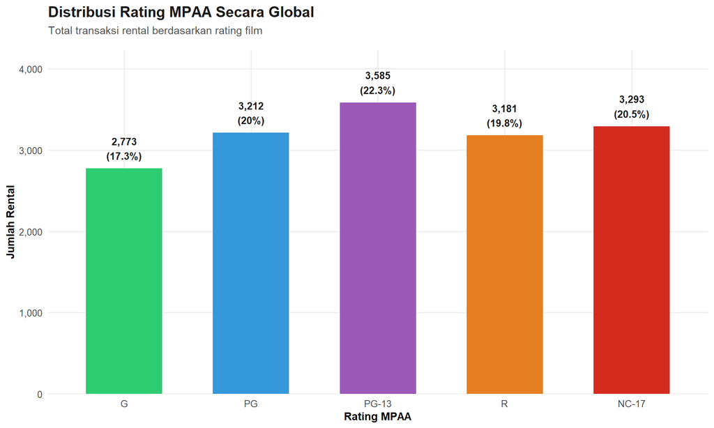

```r
df_rating_global <- df %>%
  group_by(rating) %>%
  summarise(total = sum(total_rental), .groups = "drop") %>%
  filter(total > 0) %>%
  mutate(
    rating = factor(rating, levels = c("G", "PG", "PG-13", "R", "NC-17")),
    pct    = total / sum(total) * 100
  )

ggplot(df_rating_global, aes(x = rating, y = total, fill = rating)) +
  geom_col(width = 0.6, show.legend = FALSE) +
  geom_text(aes(label = paste0(format(total, big.mark = ","), "\n(", round(pct,1), "%)")),
            vjust = -0.4, size = 3.6, fontface = "bold", color = "#1a1a1a") +
  scale_fill_manual(values = warna_rating) +
  scale_y_continuous(labels = comma, expand = expansion(mult = c(0, 0.18))) +
  labs(
    title    = "Distribusi Rating MPAA Secara Global",
    subtitle = "Total transaksi rental berdasarkan rating film",
    x = "Rating MPAA", y = "Jumlah Rental"
  ) +
  tema_sp
```

📊 **Interpretasi:** Rating **PG-13** mendominasi secara global. Ini mengindikasikan pelanggan toko DVD Sakila cenderung menyewa film untuk penonton remaja hingga dewasa. Rating **G** memiliki pangsa terkecil.

## Distribusi Genre Film Secara Global

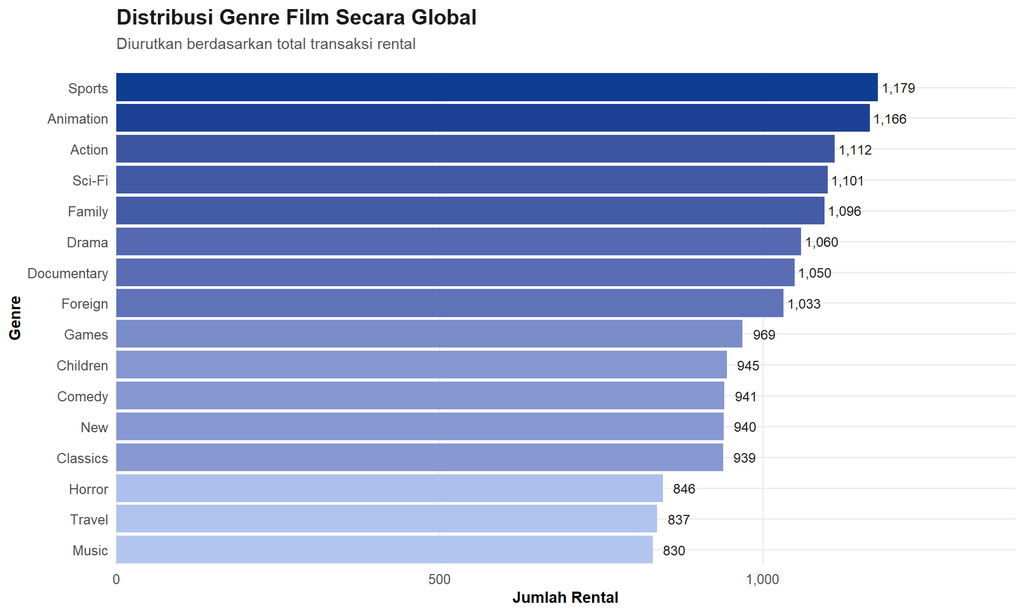

```r
df_genre_global <- df %>%
  group_by(genre) %>%
  summarise(total = sum(total_rental), .groups = "drop") %>%
  mutate(pct = total / sum(total) * 100)

ggplot(df_genre_global, aes(x = reorder(genre, total), y = total, fill = total)) +
  geom_col(show.legend = FALSE) +
  geom_text(aes(label = format(total, big.mark = ",")), hjust = -0.1, size = 3.3,
            color = "#1a1a1a") +
  coord_flip() +
  scale_fill_gradient(low = "#b3c6f0", high = "#0F3D91") +
  scale_x_discrete(expand = expansion(add = c(0.5, 0.5))) +
  scale_y_continuous(labels = comma, expand = expansion(mult = c(0, 0.18))) +
  labs(
    title    = "Distribusi Genre Film Secara Global",
    subtitle = "Diurutkan berdasarkan total transaksi rental",
    x = "Genre", y = "Jumlah Rental"
  ) +
  tema_sp
```

📊 **Interpretasi:** Genre **Sports**, **Animation**, dan **Action** mendominasi. Distribusi yang cukup merata menunjukkan koleksi toko beragam tanpa dominasi tunggal yang ekstrem.

## 15 Negara dengan Rental Tertinggi

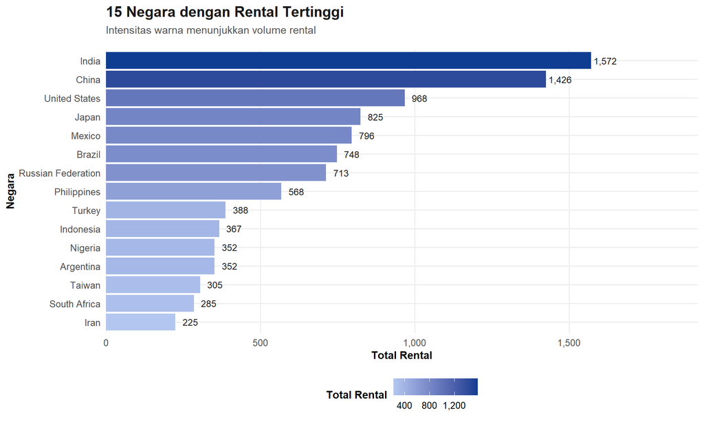

```r
top15 <- df_negara %>%
  arrange(desc(total_rental)) %>%
  slice_head(n = 15)

ggplot(top15, aes(x = reorder(negara, total_rental), y = total_rental, fill = total_rental)) +
  geom_col() +
  geom_text(aes(label = format(total_rental, big.mark = ",")),
            hjust = -0.1, size = 3.3, color = "#1a1a1a") +
  coord_flip() +
  scale_fill_gradient(low = "#b3c6f0", high = "#0F3D91", name = "Total Rental", labels = comma) +
  scale_y_continuous(labels = comma, expand = expansion(mult = c(0, 0.22))) +
  labs(
    title    = "15 Negara dengan Rental Tertinggi",
    subtitle = "Intensitas warna menunjukkan volume rental",
    x = "Negara", y = "Total Rental"
  ) +
  tema_sp
```

## Age Index per Negara

[figure not shown]

```r
ggplot(df_negara_cukup,
       aes(x = reorder(negara, age_index), y = age_index,
           color = age_index, size = total_rental)) +
  geom_hline(yintercept = c(2.5, 3.5), linetype = "dashed",
             color = "#cccccc", linewidth = 0.6) +
  geom_point(alpha = 0.85) +
  annotate("text", x = nrow(df_negara_cukup) * 0.97, y = 2.54,
           label = "Batas Muda – Campuran",
           hjust = 0, size = 3, color = "#888888") +
  annotate("text", x = nrow(df_negara_cukup) * 0.97, y = 3.54,
           label = "Batas Campuran – Dewasa",
           hjust = 0, size = 3, color = "#888888") +
  coord_flip() +
  scale_color_gradient(low = "#b3c6f0", high = "#D52B1E",
                       name = "Age Index", limits = c(1, 5)) +
  scale_size_continuous(name = "Total Rental", labels = comma, range = c(2, 11)) +
  scale_y_continuous(limits = c(1, 5.5), breaks = 1:5) +
  labs(
    title    = "Age Index per Negara",
    subtitle = "Semakin tinggi AI, semakin besar kecenderungan menonton film dewasa",
    x = "Negara", y = "Age Index (1 = termuda  ·  5 = tertua)"
  ) +
  tema_sp
```

## Heatmap Genre per 20 Negara Teratas

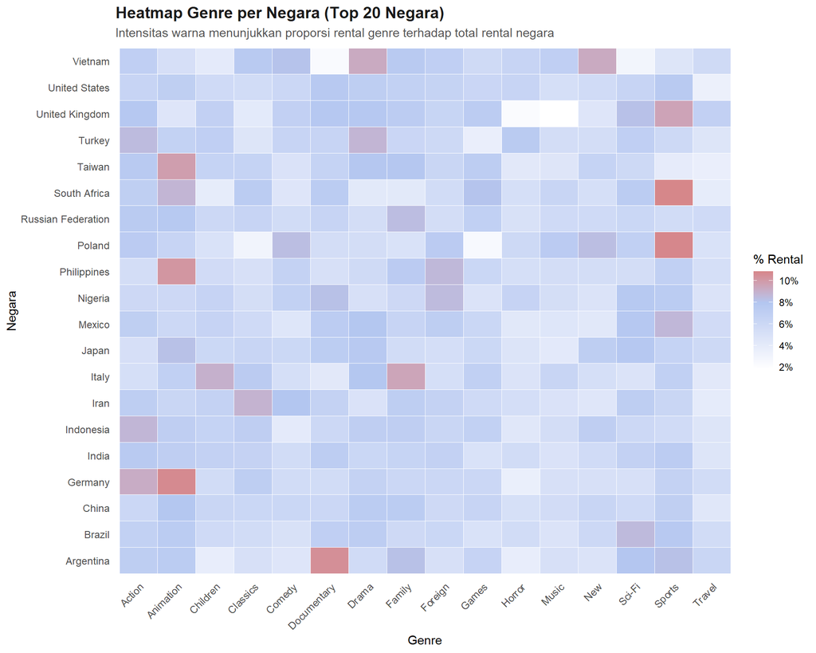

```r
top20_negara <- df_negara %>%
  arrange(desc(total_rental)) %>%
  slice_head(n = 20) %>%
  pull(negara)

df_heat <- df_genre %>% filter(negara %in% top20_negara)

ggplot(df_heat, aes(x = genre, y = negara, fill = pct)) +
  geom_tile(color = "white", linewidth = 0.35) +
  scale_fill_gradient2(
    low      = "#ffffff",
    mid      = "#b3c6f0",
    high     = "#D52B1E",
    midpoint = 8,
    name     = "% Rental",
    labels   = function(x) paste0(round(x, 1), "%")
  ) +
  labs(
    title    = "Heatmap Genre per Negara (Top 20 Negara)",
    subtitle = "Intensitas warna menunjukkan proporsi rental genre terhadap total rental negara",
    x = "Genre", y = "Negara"
  ) +
  theme_minimal(base_size = 11) +
  theme(
    axis.text.x   = element_text(angle = 45, hjust = 1, size = 9),
    axis.text.y   = element_text(size = 9),
    plot.title    = element_text(face = "bold", size = 14, color = "#1a1a1a"),
    plot.subtitle = element_text(color = "#555555"),
    legend.position = "right",
    panel.grid    = element_blank()
  )
```

📊 **Interpretasi:** Distribusi genre antar negara relatif homogen. Tidak ada dominasi ekstrem satu genre pada satu negara. Beberapa negara memperlihatkan sedikit kecenderungan pada genre **Sports** atau **Action**.

# Analisis Statistik

Uji Statistik

## Statistik Deskriptif Age Index

```r
stats_ai <- df_negara_cukup %>%
  summarise(
    Mean   = mean(age_index,   na.rm = TRUE),
    Median = median(age_index, na.rm = TRUE),
    Min    = min(age_index,    na.rm = TRUE),
    Max    = max(age_index,    na.rm = TRUE),
    SD     = sd(age_index,     na.rm = TRUE),
    IQR    = IQR(age_index,    na.rm = TRUE)
  ) %>%
  pivot_longer(everything(), names_to = "Statistik", values_to = "Nilai") %>%
  mutate(Nilai = round(Nilai, 3))

kbl(stats_ai, align = c("l", "r"),
    caption = "Tabel 1. Statistik Deskriptif Age Index antar Negara") %>%
  kable_styling(
    bootstrap_options = c("striped", "hover", "bordered"),
    full_width = FALSE, position = "left"
  ) %>%
  column_spec(1, bold = TRUE) %>%
  column_spec(2, color = "#0F3D91", bold = TRUE)
```

Tabel 1. Statistik Deskriptif Age Index antar Negara

[output not shown]

## Korelasi Spearman: Age Index vs Total Rental

- $H_0$: $\rho_s = 0$ — tidak ada korelasi monoton antara AI dan volume rental
- $H_1$: $\rho_s \neq 0$ — terdapat korelasi monoton

```r
df_cor <- df_negara_cukup %>%
  filter(is.finite(age_index), is.finite(total_rental))

if (nrow(df_cor) >= 5) {
  cor_test <- cor.test(df_cor$age_index, df_cor$total_rental,
                       method = "spearman", exact = FALSE)

  tibble(
    Statistik = c("Spearman rho (ρ)", "S statistic", "p-value"),
    Nilai     = c(round(cor_test$estimate, 4),
                  round(cor_test$statistic, 2),
                  ifelse(cor_test$p.value < 0.001, "< 0.001",
                         round(cor_test$p.value, 4)))
  ) %>%
    kbl(align = c("l", "r"),
        caption = "Tabel 2. Hasil Uji Korelasi Spearman") %>%
    kable_styling(
      bootstrap_options = c("striped", "hover", "bordered"),
      full_width = FALSE, position = "left"
    )
} else {
  cat("Data tidak cukup untuk uji korelasi Spearman (minimal 5 observasi).")
}
```

Tabel 2. Hasil Uji Korelasi Spearman

| Statistik | Nilai |
| --- | --- |
| Spearman rho (ρ) | 0.984 |
| S statistic | 3364.91 |
| p-value | < 0.001 |

# Tabel Ringkasan Negara

```r
df_negara %>%
  arrange(desc(total_rental)) %>%
  slice_head(n = 20) %>%
  mutate(
    age_index     = round(age_index, 2),
    revenue       = paste0("$", format(round(revenue, 0), big.mark = ",")),
    top_genre_pct = paste0(round(top_genre_pct, 1), "%"),
    total_rental  = format(total_rental, big.mark = ",")
  ) %>%
  select(
    Negara         = negara,
    `Total Rental` = total_rental,
    Revenue        = revenue,
    `Age Index`    = age_index,
    Segmen         = segmen,
    `Top Genre`    = top_genre,
    `% Dominasi`   = top_genre_pct,
    `Rating Dom.`  = dominant_rating
  ) %>%
  kbl(align = c("l","r","r","c","c","l","r","c"),
      caption = "Tabel 2. Ringkasan 20 Negara dengan Total Rental Tertinggi") %>%
  kable_styling(
    bootstrap_options = c("striped", "hover", "bordered", "responsive"),
    full_width = TRUE
  ) %>%
  column_spec(1, bold = TRUE) %>%
  column_spec(4, color = "#0F3D91", bold = TRUE)
```

Tabel 2. Ringkasan 20 Negara dengan Total Rental Tertinggi

[output not shown]

# Kesimpulan

Analisis terhadap data rental DVD Sakila menunjukkan bahwa preferensi film pelanggan secara global bersifat homogen dan seimbang. Dari sisi rating MPAA, **PG-13** mendominasi seluruh transaksi rental, mengindikasikan bahwa pasar terbesar adalah penonton remaja hingga dewasa muda, sementara rating G memiliki pangsa terkecil. Pada dimensi genre, **Sports**, **Animation**, dan **Action** menjadi yang paling banyak disewa secara global, namun distribusi antar genre relatif merata — tidak ada satu genre pun yang mendominasi secara absolut. Pola ini terkonfirmasi pada level per-negara melalui heatmap 20 negara teratas, yang menunjukkan tidak ada dominasi genre ekstrem di negara manapun.

⚠️ **Keterbatasan:** Rating MPAA adalah proksi usia, bukan usia asli pelanggan. Data bersifat historis dan tidak mencerminkan tren terkini.